# CITS4009 Project 2 - Modelling

Willian Herreira Lima (SID: 21840411)

28 October 2018

# Research

The aim of this research is to perform a risk assessment using machine learning models. The predictions described or depicted on this document were exclusively designed for academic practice and has no commercial value.

Some useful libraries:

# Data

## Demonstrate a full data science life cycle

This analysis aims to build knowledge and practice a series of engineered algorithms to solve a business problem. In this case, the objective is to predict prospects with a smaller risk of paying off a loan and those with a larger risk to default. Due to the academic nature of this work, it is important to highlight the similarities with the guidance or recommendations provided by Nina Zumel and John Mount on their book Practical Data Science with R.

For project 2, we worked on the: * application_train.csv, (dTrain) * application_test.csv, (dTest) * bureau.csv, (dBureau) * previous_application.csv (dPreapp)

# Relational data handling

Using some of the relational data handling techniques suggested during this course, we are going to subset the number of variables to work with, remove or treat “NA’s”, join datasets, normalize data, deal with outliers and incorporate extra information into the main Training/Testing datasets.

```r
Train_csv <- read.table('application_train.csv', header=T,sep=',',na.strings=c('NA',''))
Test_csv <- read.table('application_test.csv', header=T,sep=',',na.strings=c('NA',''))
Bureau_csv <- read.table('Bureau.csv', header=T,sep=',',na.strings=c('NA',''))
Preapp_csv <- read.table('previous_application.csv',header=T,sep=',',na.strings=c('NA',''))
```

After loading the datasets highlighted above into RStudio we performed an exploratory data analyses (EDA) identifying missing data and other anomalies which might cause undesired distortions. Due to the nature of this project, the EDA process was not described here.

In this case both Training and Test datasets were downloaded as independent files, which means that the second was not splinted from the first. In addition, the only variable which is not shared by both is “TARGET”, which is the aim of this report and is going to be added to Test as the resulting model prediction.

## Tidyng Data - Normalization

### Data Cleaning - Training and Test

Train

```r
train_subset <- select(Train_csv,SK_ID_CURR,TARGET,NAME_CONTRACT_TYPE,FLAG_OWN_CAR,FLAG_OWN_REALTY,CODE_GENDER,CNT_CHILDREN,AMT_INCOME_TOTAL,AMT_INCOME_TOTAL,AMT_CREDIT,AMT_ANNUITY,AMT_GOODS_PRICE,NAME_TYPE_SUITE,NAME_INCOME_TYPE,NAME_EDUCATION_TYPE,NAME_FAMILY_STATUS,NAME_HOUSING_TYPE,DAYS_BIRTH,DAYS_EMPLOYED,DAYS_REGISTRATION,OCCUPATION_TYPE,CNT_FAM_MEMBERS,ORGANIZATION_TYPE)

train_subset<- distinct(train_subset, SK_ID_CURR, .keep_all = TRUE)

mean_AMT_Annuity <- mean(train_subset$AMT_ANNUITY, na.rm = T)
train_subset$AMT_ANNUITY<- ifelse(is.na(train_subset$AMT_ANNUITY),mean_AMT_Annuity,
                                                 train_subset$AMT_ANNUITY)

train_subset$CNT_FAM_MEMBERS<- ifelse(is.na(train_subset$CNT_FAM_MEMBERS),0,
                                                 train_subset$CNT_FAM_MEMBERS)

mean_AMT_GOODS_PRICE <-mean(train_subset$AMT_GOODS_PRICE, na.rm = T)
train_subset$AMT_GOODS_PRICE<- ifelse(is.na(train_subset$AMT_GOODS_PRICE),mean_AMT_GOODS_PRICE,
                                                 train_subset$AMT_GOODS_PRICE)

train_subset$NAME_TYPE_SUITE<- ifelse(is.na(train_subset$NAME_TYPE_SUITE),'missing',
                                                 train_subset$NAME_TYPE_SUITE)

train_subset$OCCUPATION_TYPE<- ifelse(is.na(train_subset$OCCUPATION_TYPE),'missing',
                                                 train_subset$OCCUPATION_TYPE)
#rm(Train_csv)
```

Test

```r
test_subset <- select(Test_csv,SK_ID_CURR,NAME_CONTRACT_TYPE,FLAG_OWN_CAR,FLAG_OWN_REALTY,CODE_GENDER,CNT_CHILDREN,AMT_INCOME_TOTAL,AMT_INCOME_TOTAL,AMT_CREDIT,AMT_ANNUITY,AMT_GOODS_PRICE,NAME_TYPE_SUITE,NAME_INCOME_TYPE,NAME_EDUCATION_TYPE,NAME_FAMILY_STATUS,NAME_HOUSING_TYPE,DAYS_BIRTH,DAYS_EMPLOYED,DAYS_REGISTRATION,OCCUPATION_TYPE,CNT_FAM_MEMBERS,ORGANIZATION_TYPE)

test_subset<- distinct(test_subset, SK_ID_CURR, .keep_all = TRUE)

mean_AMT_Annuity <- mean(test_subset$AMT_ANNUITY, na.rm = T)
test_subset$AMT_ANNUITY<- ifelse(is.na(test_subset$AMT_ANNUITY),mean_AMT_Annuity,
                                                 test_subset$AMT_ANNUITY)

test_subset$CNT_FAM_MEMBERS<- ifelse(is.na(test_subset$CNT_FAM_MEMBERS),0,
                                                 test_subset$CNT_FAM_MEMBERS)

mean_AMT_GOODS_PRICE <-mean(test_subset$AMT_GOODS_PRICE, na.rm = T)
test_subset$AMT_GOODS_PRICE<- ifelse(is.na(test_subset$AMT_GOODS_PRICE),mean_AMT_GOODS_PRICE,
                                                 test_subset$AMT_GOODS_PRICE)

test_subset$NAME_TYPE_SUITE<- ifelse(is.na(test_subset$NAME_TYPE_SUITE),'missing',
                                                 test_subset$NAME_TYPE_SUITE)

test_subset$OCCUPATION_TYPE<- ifelse(is.na(test_subset$OCCUPATION_TYPE),'missing',
                                                 test_subset$OCCUPATION_TYPE)

#rm(Test_csv)
```

# Bureau

By normalizing the median of a variable named AMT_CREDIT_SUM we were able to aggregate Bureau. In addition, the NA’s of non-continuum numerical variables were replaced by the mean of that series.

```r
mean_AMT_CREDIT_SUM <-mean(Bureau_csv$AMT_CREDIT_SUM, na.rm = T)
Bureau_csv$AMT_CREDIT_SUM <- ifelse(is.na(Bureau_csv$AMT_CREDIT_SUM),
                                    mean_AMT_CREDIT_SUM,Bureau_csv$AMT_CREDIT_SUM)

mean_DAYS_CREDIT_ENDDATE<-mean(Bureau_csv$AMT_CREDIT_SUM, na.rm = T)
Bureau_csv$DAYS_CREDIT_ENDDATE<- ifelse(is.na(Bureau_csv$DAYS_CREDIT_ENDDATE),mean_DAYS_CREDIT_ENDDATE,
                                                 Bureau_csv$DAYS_CREDIT_ENDDATE)

bureau<- select(Bureau_csv,SK_ID_CURR,CREDIT_ACTIVE,CREDIT_TYPE,DAYS_CREDIT,DAYS_CREDIT_ENDDATE,DAYS_CREDIT_UPDATE, AMT_CREDIT_SUM)

bureau_aggregated<- aggregate(bureau[,'AMT_CREDIT_SUM'], list(bureau$SK_ID_CURR), median)


bureau_subset<- merge(bureau,bureau_aggregated, by.x ="SK_ID_CURR", by.y = "Group.1")
breaks <- c(0,25000, 50000, 75000, 100000, 125000, 150000, 175000, 200000,225000, 250000, 275000, 300000, 325000, 350000, 375000, 400000,425000, 450000, 475000, 500000, 525000, 550000, 575000, 600000,Inf)
bureau_subset$AMT_CREDIT_RANGE <- cut(bureau_subset$AMT_CREDIT_SUM, breaks = breaks, include.lowest = TRUE)

bureau_subset$AMT_CREDIT_GROUP<- ifelse(bureau_subset$AMT_CREDIT_SUM > 600000,Inf,bureau_subset$AMT_CREDIT_SUM)
bureau_subset$AMT_CREDIT_GROUP<- ifelse(bureau_subset$AMT_CREDIT_SUM==0,
                                        "no credit",bureau_subset$AMT_CREDIT_SUM)
bureau_subset_group <- sqldf("select * from bureau_subset where AMT_CREDIT_GROUP != 'no credit' and AMT_CREDIT_GROUP >=600000 order by sk_id_curr", row.names=TRUE)

colnames(bureau_subset_group)[colnames(bureau_subset_group)=="CREDIT_ACTIVE"] <- "BUREAU_CREDIT_ACTIVE"
colnames(bureau_subset_group)[colnames(bureau_subset_group)=="CREDIT_TYPE"] <- "BUREAU_CREDIT_TYPE"
colnames(bureau_subset_group)[colnames(bureau_subset_group)=="DAYS_CREDIT_ENDDATE"] <- "BUREAU_DAYS_CREDIT_ENDDATE"
colnames(bureau_subset_group)[colnames(bureau_subset_group)=="AMT_CREDIT_SUM"] <- "BUREAU_AMT_CREDIT_SUM"

#rm(Bureau_csv,bureau,bureau_aggregated,bureau_subset)
```

Pre-Apllication

```r
Preapp_subset<-select(Preapp_csv,SK_ID_CURR,NAME_CONTRACT_TYPE,AMT_APPLICATION,AMT_CREDIT,NAME_CASH_LOAN_PURPOSE,NAME_CONTRACT_STATUS,CODE_REJECT_REASON,NAME_CLIENT_TYPE, NAME_GOODS_CATEGORY,CHANNEL_TYPE,NFLAG_INSURED_ON_APPROVAL)

mean_AMT_CREDIT<-mean(Preapp_subset$AMT_CREDIT, na.rm = T)
Preapp_subset$AMT_CREDIT<- ifelse(is.na(Preapp_subset$AMT_CREDIT),mean_AMT_CREDIT,
                                                 Preapp_subset$AMT_CREDIT)

Preapp_subset$NAME_CONTRACT_TYPE_FIX<- ifelse(is.na(Preapp_subset$NAME_CONTRACT_TYPE),'missing',
                                                 Preapp_subset$NAME_CONTRACT_TYPE)

Preapp_subset$NFLAG_INSURED_ON_APPROVAL<- ifelse(is.na(Preapp_subset$NFLAG_INSURED_ON_APPROVAL),0,
                                                 Preapp_subset$NFLAG_INSURED_ON_APPROVAL)
Preapp_subset<- distinct(Preapp_subset, SK_ID_CURR, .keep_all = TRUE)

colnames(Preapp_subset)[colnames(Preapp_subset)=="NAME_CONTRACT_TYPE"] <- "PREAPP_NAME_CONTRACT_TYPE"
colnames(Preapp_subset)[colnames(Preapp_subset)=="AMT_APPLICATION"] <- "PREAPP_AMT_APPLICATION"
colnames(Preapp_subset)[colnames(Preapp_subset)=="NFLAG_INSURED_ON_APPROVAL"] <- "PREAPP_NFLAG_INSURED_ON_APPROVAL"
colnames(Preapp_subset)[colnames(Preapp_subset)=="CODE_REJECT_REASON"] <- "PREAPP_CODE_REJECT_REASON"
colnames(Preapp_subset)[colnames(Preapp_subset)=="NAME_CLIENT_TYPE"] <- "PREAPP_NAME_CLIENT_TYPE"
colnames(Preapp_subset)[colnames(Preapp_subset)=="CHANNEL_TYPE"] <- "PREAPP_CHANNEL_TYPE"
colnames(Preapp_subset)[colnames(Preapp_subset)=="AMT_APPLICATION"] <- "PREAPP_AMT_APPLICATION"

#rm(Preapp_csv)
```

Merging datasets

To add new variables to one dataset merge() produced the best reult.

```r
newdata<- merge(train_subset, bureau_subset_group, by="SK_ID_CURR")
dTsub <-merge(newdata, Preapp_subset,by="SK_ID_CURR")
#dTsub<- distinct(dTsub, SK_ID_CURR, .keep_all = TRUE)
```

Test

Setting the seed to the pseudorandom number generator.

```r
set.seed(2729375)
dTsub$rgroup <- runif(dim(dTsub)[[1]])
dTestsub$rgroup <- runif(dim(dTestsub)[[1]])
```

# Finding Date of Birth, Age and Time Employed.

There is a correlation between client’s age in days at the time of application and how many days before the application did client change his registration. Assuming a hypothetical last data extraction date being equal to “2016-01-01”, and if the system automatically executed a function to set a change on client’s account at the same date.

```r
today<-Sys.Date()
```

```r
dTsub$REGISTRATION_DATE<- as.Date(dTsub$DAYS_REGISTRATION, origin = as.Date("2016-01-01"))

dTsub$DATE_OF_BIRTH <- as.Date(dTsub$DAYS_BIRTH, origin=as.Date(dTsub$REGISTRATION_DATE))
date_Train<- difftime(today, dTsub$DATE_OF_BIRTH, units = "weeks")
dTsub$AGE_CUSTOMER <- as.double(date_Train)/52

dTsub$DATE_OF_EMPLOYMENT <- as.Date(dTsub$DAYS_EMPLOYED,origin=as.Date(dTsub$REGISTRATION_DATE))
d_employed <- difftime(today, dTsub$DATE_OF_EMPLOYMENT, units = "week")
dTsub$YEARS_EMPLOYED <- as.double(d_employed)/52


d_registration <- difftime(today, dTsub$REGISTRATION_DATE, units = "week")
dTsub$YEARS_REGISTERED <- as.double(d_registration)/52

#summary(dTsub$AGE_CUSTOMER)

#summary(dTsub$YEARS_EMPLOYED)
#summary(dTsub$YEARS_REGISTERED)
```

Running Test Dataset

```r
dTestsub$REGISTRATION_DATE<- as.Date(dTestsub$DAYS_REGISTRATION, origin = as.Date("2016-01-01"))

dTestsub$DATE_OF_BIRTH <- as.Date(dTestsub$DAYS_BIRTH, origin=as.Date(dTestsub$REGISTRATION_DATE))
date_Train<- difftime(today, dTestsub$DATE_OF_BIRTH, units = "weeks")
dTestsub$AGE_CUSTOMER <- as.double(date_Train)/52

dTestsub$DATE_OF_EMPLOYMENT <- as.Date(dTestsub$DAYS_EMPLOYED,origin=as.Date(dTestsub$REGISTRATION_DATE))
d_employed <- difftime(today, dTestsub$DATE_OF_EMPLOYMENT, units = "week")
dTestsub$YEARS_EMPLOYED <- as.double(d_employed)/52


d_registration <- difftime(today, dTestsub$REGISTRATION_DATE, units = "week")
dTestsub$YEARS_REGISTERED <- as.double(d_registration)/52

#summary(dTestsub$AGE_CUSTOMER)
#summary(dTestsub$YEARS_EMPLOYED)
#summary(dTestsub$YEARS_REGISTERED)
```

Due to this bank’s risk-and-control framework, a new loan contracts cannot be offered for people over 75 years of age. Therefore, the first measure for risk reduction is to have these prospects removed from the dataset.

Normalising Data by Customer age, greater than 15 and less than 75.

```r
train_subset<- sqldf("select * from dTsub where age_customer < 75 and age_customer > 15 order by sk_id_curr", row.names=TRUE)
#summary(train_subset$AGE_CUSTOMER)

test_subset<- sqldf("select * from dTestsub where age_customer < 75 and age_customer > 15 order by sk_id_curr", row.names=TRUE)
#summary(test_subset$AGE_CUSTOMER)
```

Negative numbers presented on the summary statistics regarding how many years before the application a person started his/her current employment is the root cause of a distortion. As a result, its mean is also negative, which is directly impacting my analysis due to the positive nature of time. However, it is complex to determine if a potential client is unemployed or has other income which independent of employment. Therefore, any negative numbers are going to be set as “NA”, a new variable “Employment_Time” is going to receive all observations from “YEARS_EMPLOYED” and the original observations are going to be kept for further analyses if required.

```r
train_subset$Employment_Time <-ifelse(train_subset$YEARS_EMPLOYED < 0,NA,train_subset$YEARS_EMPLOYED)
train_subset<- train_subset[!is.na(train_subset$Employment_Time),]

test_subset$Employment_Time <- ifelse(test_subset$YEARS_EMPLOYED < 0,NA,test_subset$YEARS_EMPLOYED)
test_subset<- test_subset[!is.na(test_subset$Employment_Time),]
#summary(test_subset$Employment_Time)
#summary(test_subset$Employment_Time)
```

Following the normalization process, it is applicable to the Income of the client. Observing the variable “AMT_INCOME_TOTAL” summary statistics we can conclude that the substantial max observed might also influence the analysis. Therefore, by calculating the upper whisker an initial estimate of outliers is obtained, which is > Q3+1.5*IQR = 438750. To keep some of the outliers, a new variable called “income_total” was created where 0 > income_total < 450000. In addition, to not uproot super rich prospects, the original variable is going to be kept unchanged.

```r
breaks <- c(0,25000, 50000, 75000, 100000, 125000, 150000, 175000, 200000,225000, 250000, 275000, 300000, 325000, 350000, 375000, 400000,425000, 450000, 475000, 500000,Inf)

train_subset$income_total_range <- cut(train_subset$AMT_INCOME_TOTAL, breaks = breaks, include.lowest = TRUE)
train_subset$income_total <- ifelse(train_subset$AMT_INCOME_TOTAL > 438750,NA,train_subset$AMT_INCOME_TOTAL)
train_subset<- train_subset[!is.na(train_subset$income_total),]

test_subset$income_total_range <- cut(test_subset$AMT_INCOME_TOTAL, breaks = breaks, include.lowest = TRUE)
test_subset$income_total <- ifelse(test_subset$AMT_INCOME_TOTAL > 438750,NA,test_subset$AMT_INCOME_TOTAL)
test_subset<- test_subset[!is.na(test_subset$income_total),]
#summary(train_subset$income_total)
#summary(test_subset$income_total)
```

```r
train_subset$NAME_FAMILY_STATUS <-ifelse(train_subset$NAME_FAMILY_STATUS=="Unknown",
                                         NA,train_subset$NAME_FAMILY_STATUS)
train_subset<- train_subset[!is.na(train_subset$NAME_FAMILY_STATUS),]

MEAN_AGE<- mean(train_subset$AGE_CUSTOMER)
train_subset$AGE_CUSTOMER_NORM<-train_subset$AGE_CUSTOMER/MEAN_AGE


test_subset$NAME_FAMILY_STATUS <- ifelse(test_subset$NAME_FAMILY_STATUS=="Unknown",
                                         NA,test_subset$NAME_FAMILY_STATUS)
test_subset<- test_subset[!is.na(test_subset$NAME_FAMILY_STATUS),]

MEAN_AGE_T<- mean(test_subset$AGE_CUSTOMER)
test_subset$AGE_CUSTOMER_NORM<-test_subset$AGE_CUSTOMER/MEAN_AGE_T
```

The boxplot below depicts the similarities of Training and Testing datasets.

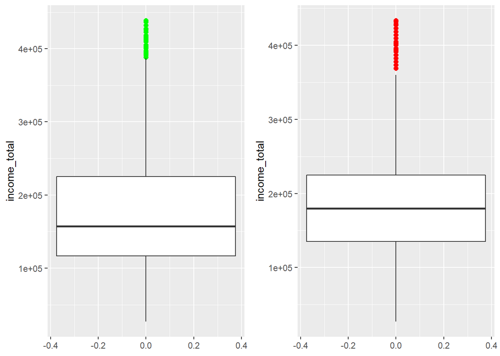

```r
p1<- ggplot(train_subset)+ geom_boxplot(aes(y=income_total), outlier.colour = "green", outlier.shape = 16,
                           outlier.size = 2, notch = FALSE)
p2<- ggplot(test_subset)+ geom_boxplot(aes(y=income_total), outlier.colour = "red", outlier.shape = 16,
                           outlier.size = 2, notch = FALSE)
grid.arrange(p1,p2,ncol=2)
```

In summary, both datasets have now the same variables, with unique ID’s of loan in our sample and has some normalised data which is going to support findings. Moving forward, the boxplot shows that at this point both datasets are aligned and are ready to be analysed.

# But before starting, to amount of observation to be dealt with are going to delay the analysis. For this reason, it was necessary to extract a sample dataset from Train and Test which is equal to 10% of its original size.

```r
train_subset$gp <- runif(dim(train_subset)[1])
Train <- subset(train_subset, train_subset$gp <= 0.1)

test_subset$gp <- runif(dim(test_subset)[1])
Test_s<- subset(test_subset, test_subset$gp <= 0.1)
```

# Modelling

This model aims to identify those who are less likely to default when getting a loan from a financial institution. Warning, some of the results presented here are of academic interest and shall not be used on a commercial environment.

# Training

After having applied some best practices of Relational Data Handling which resulted on two nearly identical datasets (Train and Test), they are now ready to have some Modelling techniques applied. This analysis is going to work with Train and by isolating the Test dataset we are going to have an unbiased result at the end.

This analysis has “TARGET” as its Response Variable. Question is, which variables are risk factors for credit?

To perform this research, two other datasets were joint to the original file which are Credit Bureau, containing all client’s previous credit provided by other financial institutions, and Previous Applications which has all preceding loan requests from our prospects. This model is going to deal with 53 variables to run its statistical analysis.

For the first steps of this model, we are going to:

- Identify which features are Categorical or Numerical Variables
- Split the Training Model in three:
  - Training Dataset
  - Test Dataset
  - Calibration Dataset

```r
TrainAll<- subset(Train, rgroup<=0.9)
Test<- subset(Train, rgroup>0.9)
outcome=c('TARGET')
vars<- setdiff(colnames(TrainAll), c(outcome,'rgroup'))
catVars<- vars[sapply(TrainAll[,vars],class) %in% c('factor', 'character')]
numericVars<- vars[sapply(TrainAll[,vars], class) %in% c('numeric', 'integer')]
#rm(Train_df)
outcome <- 'TARGET'
pos<- '1'

#Split training data into training and calibration
useForCal <- rbinom(n=dim(TrainAll)[[1]], size = 1, prob = 0.1)>0
dCal<- subset(TrainAll, useForCal)
d_Train <- subset(TrainAll, !useForCal)

#rm(train_subset,test_subset) # Remove Train and Test subsets
```

## Single Variable Model

```r
table_1<- table(NAME_CLIENT_TYPE=d_Train[,'NAME_HOUSING_TYPE'],TARGET=d_Train[,outcome])
print(table_1)
```

```
##                      TARGET
## NAME_CLIENT_TYPE          0     1
##   Co-op apartment        79    13
##   House / apartment   14263  1282
##   Municipal apartment   511    46
##   Office apartment      170    11
##   Rented apartment      251    39
##   With parents          899   126
```

compare the percentage rate of clients with and without payment difficulties

```r
print(round((table_1[,]/(sum(table_1)))*100),digits = 3)
```

```
##                      TARGET
## NAME_CLIENT_TYPE       0  1
##   Co-op apartment      0  0
##   House / apartment   81  7
##   Municipal apartment  3  0
##   Office apartment     1  0
##   Rented apartment     1  0
##   With parents         5  1
```

However, it might not be taken as true because other variables may change this scenario. Nonethless, it indeed give us a good start for our analysis.

# Function to build single-variable models for categorical variables

This function predicts all categorical variables.

```r
mkPredC <- function(outCol,varCol,appCol) {
  pPos <- sum(outCol<=pos)/length(outCol)
  naTab <- table(as.factor(outCol[is.na(varCol)]))
  pPosWna <- (naTab/sum(naTab))[pos]
  vTab <- table(as.factor(outCol),varCol)
  pPosWv <- (vTab[pos,]+1.0e-3*pPos)/(colSums(vTab)+1.0e-3)
  pred <- pPosWv[appCol]
  pred[is.na(appCol)] <- pPosWna
  pred[is.na(pred)] <- pPos
  pred
}
```

```r
for(TARGET in catVars) {
  pi <- paste('pred',TARGET,sep='')
  d_Train[,pi] <- mkPredC(d_Train[,outcome],d_Train[,TARGET],d_Train[,TARGET])
  dCal[,pi] <- mkPredC(d_Train[,outcome],d_Train[,TARGET],dCal[,TARGET])
  Test[,pi] <- mkPredC(d_Train[,outcome],d_Train[,TARGET],Test[,TARGET])
  }
head(catVars)
```

```
## [1] "NAME_CONTRACT_TYPE" "FLAG_OWN_CAR"       "FLAG_OWN_REALTY"
## [4] "CODE_GENDER"        "NAME_TYPE_SUITE"    "NAME_INCOME_TYPE"
```

# Scoring categorical variables by AUC

When scoring our categorical variables the model avoid overfiting, here we are selecting only those varibles which the AUC is greater then or iqual to 0.55.

```r
calcAUC <- function(predcol,outcol) {
  perf <- performance(prediction(predcol,outcol>=pos),'auc')
  as.numeric(perf@y.values)
}

for(TARGET in catVars) {
  pi <- paste('pred',TARGET,sep='')
  aucTrain <- calcAUC(d_Train[,pi],d_Train[,outcome])
  if(aucTrain>=0.55) {
    aucCal <- calcAUC(dCal[,pi],dCal[,outcome])
    print(sprintf("%s, trainAUC: %4.3f calibrationAUC: %4.3f",
                  pi,aucTrain,aucCal))
  }
}
```

```
## [1] "predNAME_EDUCATION_TYPE, trainAUC: 0.558 calibrationAUC: 0.525"
## [1] "predOCCUPATION_TYPE, trainAUC: 0.570 calibrationAUC: 0.531"
## [1] "predORGANIZATION_TYPE, trainAUC: 0.571 calibrationAUC: 0.536"
## [1] "predAMT_CREDIT_GROUP, trainAUC: 0.894 calibrationAUC: 0.482"
## [1] "predNAME_GOODS_CATEGORY, trainAUC: 0.564 calibrationAUC: 0.534"
## [1] "predPREAPP_CHANNEL_TYPE, trainAUC: 0.550 calibrationAUC: 0.521"
```